# Amount of Time Being Served in PAC

Some things to note:

- Not sure if total duration as denoted by the difference between `PAC Registration Time` and `PAC End Time` is a better fit than the `PAC Consult Duration`.
- Hence, both distributions are included.
- We are also looking preliminarily into other histograms, though we are not sure what to use it for yet.
- `PAC Consult Duration` is for >= 15 minutes, then translated to start at 0 instead. **Not sure if this is correct.**
- We should decide on whether to split based on ASA, Department or both.

Some questions:

- Clarify that:
  - Visit time = time allocated
  - Listing date = when did they set the consult timing
  - Register time = when did they come
  - End time = when did they leave
  - Consult duration = how long to consult per se
- Department names:
  - e.g. DDR/HPB is it the same as HPB?
  - e.g. H&N ENT is it the same as ENT?
  - Maybe can have a brief explanation so that we can try to cluster things
- How was PAC registration/end time calculated?

# 1 Histograms

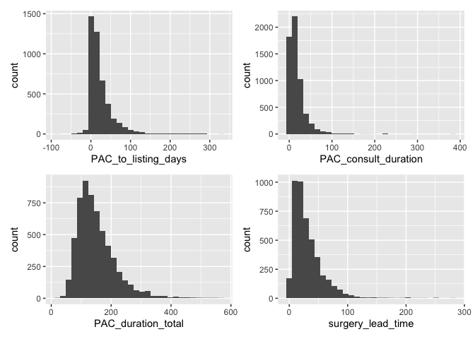

# 2 Cullen and Frey Graphs

In order of:

1. `PAC_to_listing_days`
2. `PAC_consult_duration`
3. `PAC_duration_total`
4. `surgery_lead_time`

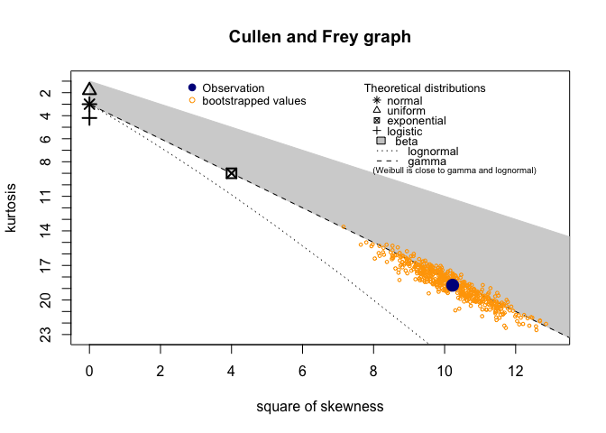

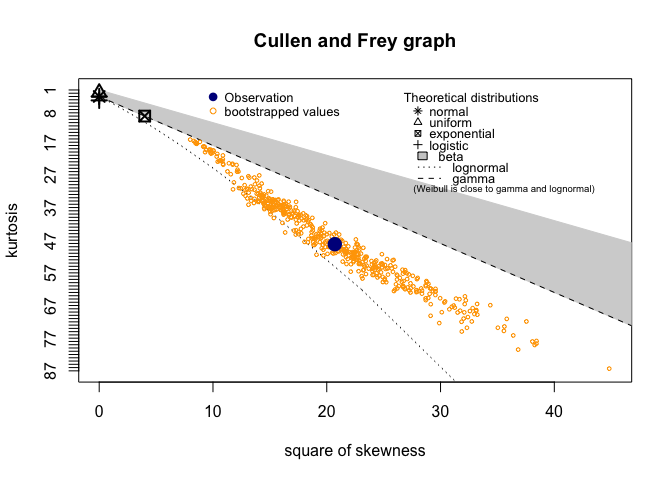

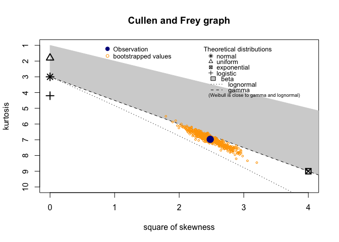

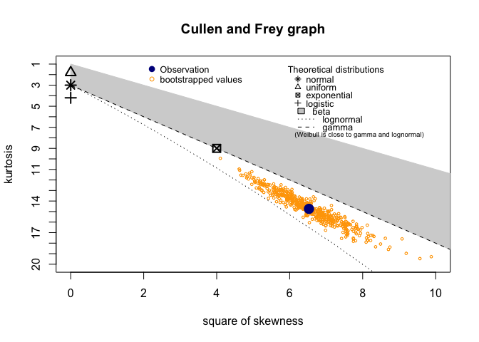

```
## $PAC_to_listing_days
## summary statistics
## ------
## min:  -88   max:  326
## median:  13
## mean:  24.10368
## estimated sd:  32.02378
## estimated skewness:  3.197476
## estimated kurtosis:  18.71722
##
## $PAC_consult_duration
## summary statistics
## ------
## min:  0   max:  384
## median:  12
## mean:  17.76114
## estimated sd:  21.25082
## estimated skewness:  4.550498
## estimated kurtosis:  48.22152
##
## $PAC_duration_total
## summary statistics
## ------
## min:  25   max:  573
## median:  136
## mean:  149.8356
## estimated sd:  65.56147
## estimated skewness:  1.575021
## estimated kurtosis:  6.972619
##
## $surgery_lead_time
## summary statistics
## ------
## min:  0   max:  281
## median:  25
## mean:  31.79806
## estimated sd:  27.08426
## estimated skewness:  2.555058
## estimated kurtosis:  14.74403
```

# 3 Distribution for Consult Duration

**Disclaimer**: distributions are not validated by chi-squared test yet but through other tests. Will need to ask James about these too. Will do the chi-squared tests soon.

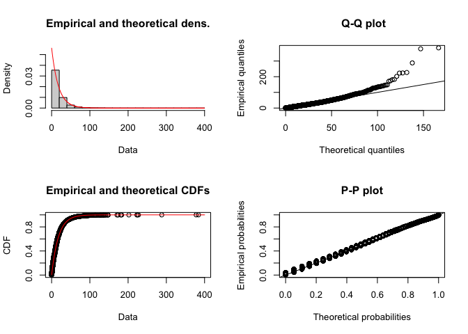

```
## [[1]]
## Goodness-of-fit statistics
##                               1-mle-exp
## Kolmogorov-Smirnov statistic 0.04387912
## Cramer-von Mises statistic   1.73260324
## Anderson-Darling statistic          Inf
##
## Goodness-of-fit criteria
##                                1-mle-exp
## Akaike's Information Criterion  45417.33
## Bayesian Information Criterion  45424.01
##
## [[2]]
## Fitting of the distribution ' exp ' by maximum likelihood
## Parameters :
##        estimate   Std. Error
## rate 0.05630269 0.0007354522
## Loglikelihood:  -22707.66   AIC:  45417.33   BIC:  45424.01
```

# 4 Distribution for Total Duration

**Disclaimer**: distributions are not validated by chi-squared test yet but through other tests. Will need to ask James about these too. Will do the chi-squared tests soon.

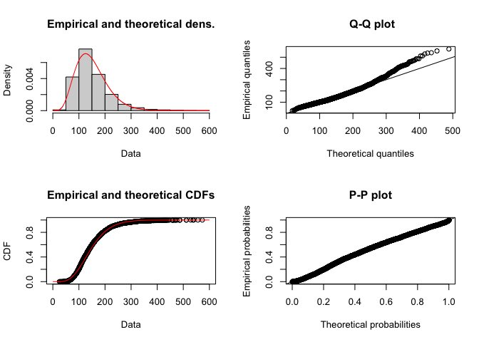

```
## [[1]]
## Goodness-of-fit statistics
##                              1-mle-gamma
## Kolmogorov-Smirnov statistic  0.04743222
## Cramer-von Mises statistic    4.32292125
## Anderson-Darling statistic   26.66474914
##
## Goodness-of-fit criteria
##                                1-mle-gamma
## Akaike's Information Criterion    64010.95
## Bayesian Information Criterion    64024.31
##
## [[2]]
## Fitting of the distribution ' gamma ' by maximum likelihood
## Parameters :
##         estimate   Std. Error
## shape 6.14632229 0.1101243012
## rate  0.04102342 0.0007654273
## Loglikelihood:  -32003.48   AIC:  64010.95   BIC:  64024.31
## Correlation matrix:
##           shape      rate
## shape 1.0000000 0.9593236
## rate  0.9593236 1.0000000
```